# R Notebook

```r
library(CCA)
library(candisc)
library(ACSWR)
data(chemicaldata)
names(chemicaldata)
chemicaldata
```

Digunakan dataset chemicaldata (Box and Youle 1955; Rencher2002) yang terdapat pada package ACSWR. Dataset chemicaldata berisi hasil eksperimen reaksi kimia, dimana dalam eksperimen ini variabel yang digunakan adalah : X1 = temperatur X2 = konsentrasi zat X3 = waktu Y1 = persentase material yang tidak berubah Y2 = persentase material yang berubah sesuai yang diharapkan Y3 = persentase material yang berubah tidak sesuai yang diharapkan

```r
# Standardisasi dulu
data <- as.data.frame(scale(chemicaldata))
col1 <- 4:6
col2 <- 1:3

data1 <- data[,col1]
data2 <- data[,col2]

p <- ncol(data1)
q <- ncol(data2)
n <- nrow(data)
min.pq <- min(p,q)
```

Persebaran Data

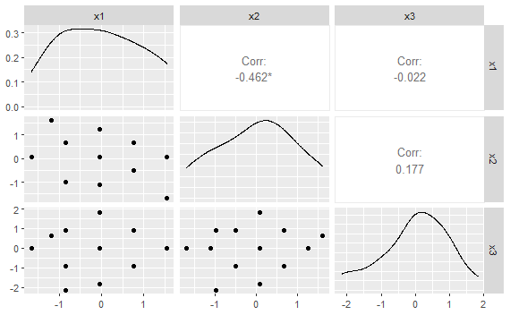

```r
library(GGally)
ggpairs(data1)
```

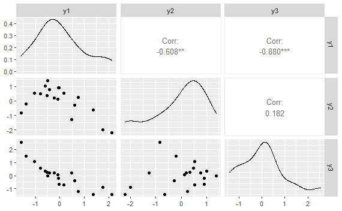

```r
ggpairs(data2)
```

Keterkaitan linier

```r
library(CCA)
correl<-matcor(data1, data2)
correl
```

```
$Xcor
            x1         x2          x3
x1  1.00000000 -0.4620014 -0.02188275
x2 -0.46200145  1.0000000  0.17665667
x3 -0.02188275  0.1766567  1.00000000

$Ycor
           y1         y2         y3
y1  1.0000000 -0.6078234 -0.8804014
y2 -0.6078234  1.0000000  0.1822497
y3 -0.8804014  0.1822497  1.0000000

$XYcor
            x1          x2          x3         y1          y2         y3
x1  1.00000000 -0.46200145 -0.02188275 -0.6769387  0.40395099  0.5768977
x2 -0.46200145  1.00000000  0.17665667 -0.2247259  0.07998377  0.2255903
x3 -0.02188275  0.17665667  1.00000000 -0.4525396  0.39273121  0.3615240
y1 -0.67693865 -0.22472586 -0.45253956  1.0000000 -0.60782343 -0.8804014
y2  0.40395099  0.07998377  0.39273121 -0.6078234  1.00000000  0.1822497
y3  0.57689773  0.22559034  0.36152405 -0.8804014  0.18224967  1.0000000
```

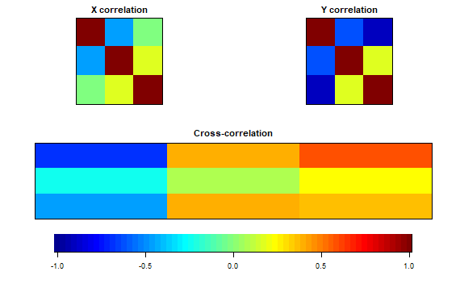

```r
img.matcor(correl,type=2)
```

# Dengan Package candisc

```r
library(candisc)
cc1 <- candisc::cancor(data1, data2) # Ada uji signifikansinya dan Summary dari Variat Kanoniknya
summary(cc1)
```

```
Canonical correlation analysis of:
     3   X  variables:  x1, x2, x3
  with   3   Y  variables:  y1, y2, y3
```

| CanR | CanRSQ | Eigen | percent | cum | scree |
| --- | --- | --- | --- | --- | --- |
| 0.98152665 | 0.963394567 | 26.318349223 | 99.60771042 | 99.60771 | ****************************** |
| 0.30199414 | 0.091200458 | 0.100352668 | 0.37980724 | 99.98752 |  |
| 0.05733448 | 0.003287242 | 0.003298084 | 0.01248234 | 100.00000 |  |

```
Test of H0: The canonical correlations in the
current row and all that follow are zero

     CanR LR test stat approx F numDF  denDF   Pr(> F)
1 0.98153      0.03316  10.7870     9 31.789 1.884e-07 ***
2 0.30199      0.90581   0.3549     4 28.000    0.8384
3 0.05733      0.99671   0.0495     1 15.000    0.8270
---
Signif. codes:  0 ‘***’ 0.001 ‘**’ 0.01 ‘*’ 0.05 ‘.’ 0.1 ‘ ’ 1

Raw canonical coefficients

   X  variables:
      Xcan1    Xcan2     Xcan3
x1 -0.99883 -0.43183 -0.305300
x2 -0.62962 -0.51513  0.809984
x3 -0.35221  0.95354  0.061545

   Y  variables:
     Ycan1  Ycan2  Ycan3
y1 1.70192 6.2374 3.7599
y2 0.32592 3.4432 1.0250
y3 0.57747 4.7956 3.6266
```

Korelasi kanonik

```r
(rho <- cc1$cancor) # Korelasi kanonik
```

```
[1] 0.98152665 0.30199414 0.05733448
```

Koefisien dari Variat Kanonik

```r
cc1$coef
```

```
$X
        Xcan1      Xcan2       Xcan3
x1 -0.9988316 -0.4318281 -0.30530044
x2 -0.6296241 -0.5151350  0.80998368
x3 -0.3522073  0.9535361  0.06154487

$Y
       Ycan1    Ycan2    Ycan3
y1 1.7019208 6.237351 3.759917
y2 0.3259174 3.443189 1.024953
y3 0.5774680 4.795627 3.626580
```

Koefisien dari Variat Kanonik yang distandardisasi (Jika data yang digunakan belum distandardisasi)

```r
V11.sqrt <- diag(sqrt(diag(cov(data1))))
V22.sqrt <- diag(sqrt(diag(cov(data2))))

V11.sqrt %*% cc1$coef$X
```

```
          Xcan1      Xcan2       Xcan3
[1,] -0.9988316 -0.4318281 -0.30530044
[2,] -0.6296241 -0.5151350  0.80998368
[3,] -0.3522073  0.9535361  0.06154487
```

```r
V22.sqrt %*% cc1$coef$Y
```

```
         Ycan1    Ycan2    Ycan3
[1,] 1.7019208 6.237351 3.759917
[2,] 0.3259174 3.443189 1.024953
[3,] 0.5774680 4.795627 3.626580
```

Korelasi

```r
cc1$structure$X.xscores # Korelasi X dengan U
```

```
        Xcan1      Xcan2      Xcan3
x1 -0.7002371 -0.2147010 -0.6808608
x2 -0.2303823 -0.1471813  0.9619052
x3 -0.4415774  0.8719836  0.2113147
```

```r
cc1$structure$Y.yscores # Korelasi Y dengan V
```

```
        Ycan1       Ycan2       Ycan3
y1  0.9954170 -0.07757607 -0.05591924
y2 -0.6033066  0.52598224 -0.59946959
y3 -0.8615072 -0.06822615  0.50314074
```

```r
cc1$structure$X.yscores # Korelasi X dengan V
```

```
        Ycan1       Ycan2       Ycan3
x1 -0.6873014 -0.06483844 -0.03903680
x2 -0.2261263 -0.04444788  0.05515033
x3 -0.4334200  0.26333395  0.01211562
```

```r
cc1$structure$Y.xscores # Korelasi Y dengan U
```

```
        Xcan1       Xcan2       Xcan3
y1  0.9770283 -0.02342752 -0.00320610
y2 -0.5921615  0.15884355 -0.03437028
y3 -0.8455922 -0.02060390  0.02884731
```

Scores

```r
cc1$scores # Scores
```

```
$X
             Xcan1       Xcan2       Xcan3
 [1,]  2.230504539 -1.16584543 -0.67087105
 [2,]  1.152094308  1.75375064 -0.48242915
 [3,]  0.758876244 -0.84911235  0.74275969
 [4,]  0.111830106  0.90264530  0.85582484
 [5,] -0.104246314 -0.93557992 -0.70407353
 [6,] -0.751292453  0.81617773 -0.59100839
 [7,] -0.847292173 -1.54351231  0.25182217
 [8,] -1.494338312  0.20824534  0.36488731
 [9,]  0.003791896 -0.01646731  0.07587565
[10,] -1.602376522 -0.71086727 -0.41506187
[11,]  1.609960313  0.67793265  0.56681317
[12,] -0.739253963 -0.62439970  1.03177136
[13,]  0.746837755  0.59146508 -0.88002005
```

[output cut: 28 more lines]

# Dengan Package CCA

Korelasi kanonik

```r
library(CCA)
cc2 <- cc(data1, data2)

(rho <- cc2$cor) # Korelasi Kanonik
```

```
[1] 0.98152665 0.30199414 0.05733448
```

Uji Signifikansi Korelasi Kanonik

```r
library(CCP)
p.asym(rho, n, p, q, tstat = "Wilks")
```

```
Wilks' Lambda, using F-approximation (Rao's F):
               stat      approx df1      df2      p.value
1 to 3:  0.03315764 10.78695611   9 31.78919 1.883914e-07
2 to 3:  0.90581210  0.35493742   4 28.00000 8.383815e-01
3 to 3:  0.99671276  0.04947126   1 15.00000 8.269860e-01
```

```r
p.asym(rho, n, p, q, tstat = "Hotelling")
```

```
 Hotelling-Lawley Trace, using F-approximation:
                 stat      approx df1 df2      p.value
1 to 3:  26.421999975 34.25074071   9  35 9.103829e-15
2 to 3:   0.103650752  0.35414007   4  41 8.396454e-01
3 to 3:   0.003298084  0.05166998   1  47 8.211683e-01
```

```r
p.asym(rho, n, p, q, tstat = "Pillai")
```

```
 Pillai-Bartlett Trace, using F-approximation:
                stat     approx df1 df2    p.value
1 to 3:  1.057882268 2.72352765   9  45 0.01262562
2 to 3:  0.094487701 0.41463193   4  51 0.79729324
3 to 3:  0.003287242 0.06252612   1  57 0.80344600
```

```r
p.asym(rho, n, p, q, tstat = "Roy")
```

```
 Roy's Largest Root, using F-approximation:
              stat   approx df1 df2      p.value
1 to 1:  0.9633946 131.5917   3  15 5.373324e-11

 F statistic for Roy's Greatest Root is an upper bound.
```

Koefisien dari Variat Kanonik

```r
cc2[3:4]
```

```
$xcoef
         [,1]       [,2]        [,3]
x1 -0.9988316 -0.4318281 -0.30530044
x2 -0.6296241 -0.5151350  0.80998368
x3 -0.3522073  0.9535361  0.06154487

$ycoef
        [,1]     [,2]     [,3]
y1 1.7019208 6.237351 3.759917
y2 0.3259174 3.443189 1.024953
y3 0.5774680 4.795627 3.626580
```

Koefisien dari Variat Kanonik yang distandardisasi (Jika data yang digunakan belum distandardisasi)

```r
V11.sqrt <- diag(sqrt(diag(cov(data1))))
V22.sqrt <- diag(sqrt(diag(cov(data2))))

V11.sqrt %*% cc2$xcoef
```

```
           [,1]       [,2]        [,3]
[1,] -0.9988316 -0.4318281 -0.30530044
[2,] -0.6296241 -0.5151350  0.80998368
[3,] -0.3522073  0.9535361  0.06154487
```

```r
V22.sqrt %*% cc2$ycoef
```

```
          [,1]     [,2]     [,3]
[1,] 1.7019208 6.237351 3.759917
[2,] 0.3259174 3.443189 1.024953
[3,] 0.5774680 4.795627 3.626580
```

Korelasi

```r
cc2$scores[c(3,6,5,4)] # Korelasi
```

```
$corr.X.xscores
         [,1]       [,2]       [,3]
x1 -0.7002371 -0.2147010 -0.6808608
x2 -0.2303823 -0.1471813  0.9619052
x3 -0.4415774  0.8719836  0.2113147

$corr.Y.yscores
         [,1]        [,2]        [,3]
y1  0.9954170 -0.07757607 -0.05591924
y2 -0.6033066  0.52598224 -0.59946959
y3 -0.8615072 -0.06822615  0.50314074

$corr.X.yscores
         [,1]        [,2]        [,3]
x1 -0.6873014 -0.06483844 -0.03903680
x2 -0.2261263 -0.04444788  0.05515033
x3 -0.4334200  0.26333395  0.01211562

$corr.Y.xscores
         [,1]        [,2]        [,3]
y1  0.9770283 -0.02342752 -0.00320610
y2 -0.5921615  0.15884355 -0.03437028
y3 -0.8455922 -0.02060390  0.02884731
```

Scores

```r
cc2$scores[1:2] # Scores
```

```
$xscores
              [,1]        [,2]        [,3]
 [1,]  2.230504539 -1.16584543 -0.67087105
 [2,]  1.152094308  1.75375064 -0.48242915
 [3,]  0.758876244 -0.84911235  0.74275969
 [4,]  0.111830106  0.90264530  0.85582484
 [5,] -0.104246314 -0.93557992 -0.70407353
 [6,] -0.751292453  0.81617773 -0.59100839
 [7,] -0.847292173 -1.54351231  0.25182217
 [8,] -1.494338312  0.20824534  0.36488731
 [9,]  0.003791896 -0.01646731  0.07587565
[10,] -1.602376522 -0.71086727 -0.41506187
[11,]  1.609960313  0.67793265  0.56681317
[12,] -0.739253963 -0.62439970  1.03177136
[13,]  0.746837755  0.59146508 -0.88002005
```

[output cut: 28 more lines]

# Manual

Matriks kovarians

```r
S11 <- cov(data1)
S22 <- cov(data2)
S12 <- cov(data1, data2)
S21 <- cov(data2, data1)
```

Eigen

```r
# Function untuk mencari akar invers matriks
sqrt_inv <- function(M) {
  eig <- eigen(M)
  result <- 1/sqrt(eig$values[1]) * eig$vectors[,1] %*% t(eig$vectors[,1])
  for (i in 2:ncol(M)) {
    result <- result + 1/sqrt(eig$values[i]) * eig$vectors[,i] %*% t(eig$vectors[,i])
  }
  result
}

S11.sqrt.inv <- sqrt_inv(S11)
S22.sqrt.inv <- sqrt_inv(S22)

# Cara lain
library(expm)
S11.sqrt.inv <- solve(sqrtm(S11))
S22.sqrt.inv <- solve(sqrtm(S22))

M1 <- S11.sqrt.inv%*%S12%*%solve(S22)%*%S21%*%S11.sqrt.inv
M2 <- S22.sqrt.inv%*%S21%*%solve(S11)%*%S12%*%S22.sqrt.inv

eig.M1 <- eigen(M1) # vektor eigennya disebut e
eig.M2 <- eigen(M2) # vektor eigennya disebut f
```

Korelasi Kanonik

```r
sqrt(eig.M1$values)[1:min.pq]
```

```
[1] 0.98152665 0.30199414 0.05733448
```

```r
(rho <- sqrt(eig.M2$values)[1:min.pq])
```

```
[1] 0.98152665 0.30199414 0.05733448
```

Uji Signifikansi Korelasi Kanonik

```r
library(CCP)
p.asym(rho, n, p, q, tstat = "Wilks")
```

```
Wilks' Lambda, using F-approximation (Rao's F):
               stat      approx df1      df2      p.value
1 to 3:  0.03315764 10.78695611   9 31.78919 1.883914e-07
2 to 3:  0.90581210  0.35493742   4 28.00000 8.383815e-01
3 to 3:  0.99671276  0.04947126   1 15.00000 8.269860e-01
```

```r
p.asym(rho, n, p, q, tstat = "Hotelling")
```

```
 Hotelling-Lawley Trace, using F-approximation:
                 stat      approx df1 df2      p.value
1 to 3:  26.421999975 34.25074071   9  35 9.103829e-15
2 to 3:   0.103650752  0.35414007   4  41 8.396454e-01
3 to 3:   0.003298084  0.05166998   1  47 8.211683e-01
```

```r
p.asym(rho, n, p, q, tstat = "Pillai")
```

```
 Pillai-Bartlett Trace, using F-approximation:
                stat     approx df1 df2    p.value
1 to 3:  1.057882268 2.72352765   9  45 0.01262562
2 to 3:  0.094487701 0.41463193   4  51 0.79729324
3 to 3:  0.003287242 0.06252612   1  57 0.80344600
```

```r
p.asym(rho, n, p, q, tstat = "Roy")
```

```
 Roy's Largest Root, using F-approximation:
              stat   approx df1 df2      p.value
1 to 1:  0.9633946 131.5917   3  15 5.373324e-11

 F statistic for Roy's Greatest Root is an upper bound.
```

Koefisien dari Variat Kanonik U

```r
a <- S11.sqrt.inv %*% eig.M1$vectors[,1:min.pq]
rownames(a) <- colnames(data1)
a
```

```
         [,1]       [,2]        [,3]
x1 -0.9988316 -0.4318281  0.30530044
x2 -0.6296241 -0.5151350 -0.80998368
x3 -0.3522073  0.9535361 -0.06154487
```

Koefisien dari Variat Kanonik V

```r
b <- S22.sqrt.inv %*% eig.M2$vectors[,1:min.pq]
rownames(b) <- colnames(data2)
b
```

```
        [,1]      [,2]     [,3]
y1 1.7019208 -6.237351 3.759917
y2 0.3259174 -3.443189 1.024953
y3 0.5774680 -4.795627 3.626580
```

Koefisien dari Variat Kanonik yang distandardisasi (Jika data yang digunakan belum distandardisasi)

```r
V11.sqrt <- diag(sqrt(diag(cov(data1))))
V22.sqrt <- diag(sqrt(diag(cov(data2))))

V11.sqrt %*% a
```

```
           [,1]       [,2]        [,3]
[1,] -0.9988316 -0.4318281  0.30530044
[2,] -0.6296241 -0.5151350 -0.80998368
[3,] -0.3522073  0.9535361 -0.06154487
```

```r
V22.sqrt %*% b
```

```
          [,1]      [,2]     [,3]
[1,] 1.7019208 -6.237351 3.759917
[2,] 0.3259174 -3.443189 1.024953
[3,] 0.5774680 -4.795627 3.626580
```

Scores U (Nilai Variat Kanonik U)

```r
(U <- as.matrix(data1) %*% a)
```

```
              [,1]        [,2]        [,3]
 [1,]  2.230504539 -1.16584543  0.67087105
 [2,]  1.152094308  1.75375064  0.48242915
 [3,]  0.758876244 -0.84911235 -0.74275969
 [4,]  0.111830106  0.90264530 -0.85582484
 [5,] -0.104246314 -0.93557992  0.70407353
 [6,] -0.751292453  0.81617773  0.59100839
 [7,] -0.847292173 -1.54351231 -0.25182217
 [8,] -1.494338312  0.20824534 -0.36488731
 [9,]  0.003791896 -0.01646731 -0.07587565
[10,] -1.602376522 -0.71086727  0.41506187
[11,]  1.609960313  0.67793265 -0.56681317
[12,] -0.739253963 -0.62439970 -1.03177136
[13,]  0.746837755  0.59146508  0.88002005
[14,] -0.643254243  1.73529034 -0.18894079
[15,]  0.650838034 -1.76822496  0.03718949
[16,] -0.487807733  0.20103131  1.84890543
[17,] -0.487807733  0.20103131  1.84890543
[18,] -0.053531875  0.26321977 -1.69988471
[19,] -0.053531875  0.26321977 -1.69988471
```

Scores V (Nilai Variat Kanonik V)

```r
(V <- as.matrix(data2) %*% b)
```

```
             [,1]       [,2]         [,3]
 [1,]  2.09778362  1.1041111  0.611132567
 [2,]  1.29398950  0.5219566 -0.686230525
 [3,]  0.67109241  0.2051390 -1.266743130
 [4,]  0.01937793  0.6597517 -1.469499523
 [5,] -0.14651111  0.3299210 -1.649740910
 [6,] -0.61377318  0.7334426 -0.614024293
 [7,] -0.88747010  0.6938741 -0.516054185
 [8,] -1.50650496  0.5426948  2.432288140
 [9,] -0.06693847 -0.2285540  0.068736060
[10,] -1.55848793  2.1700100 -0.004206386
[11,]  1.80117275  0.3206936  1.243361361
[12,] -0.18408905 -0.3482939  0.150233450
[13,]  0.73985934 -1.0849391  0.680133375
[14,] -0.95917850 -0.5800591  0.567780019
[15,]  0.51920558  0.4512992  1.216491428
[16,] -0.51895573 -1.2512678 -0.064387766
[17,] -0.40410523 -1.6144702 -0.497884842
[18,] -0.36477628 -0.9335076 -0.109333771
[19,]  0.06830943 -1.6918019 -0.092051069
```

Korelasi

```r
V11.sqrt.inv <- solve(diag(sqrt(diag(cov(data1)))))
V22.sqrt.inv <- solve(diag(sqrt(diag(cov(data2)))))

V11.sqrt.inv %*% S11 %*% a # Korelasi X dengan U
```

```
           [,1]       [,2]       [,3]
[1,] -0.7002371 -0.2147010  0.6808608
[2,] -0.2303823 -0.1471813 -0.9619052
[3,] -0.4415774  0.8719836 -0.2113147
```

```r
V22.sqrt.inv %*% S22 %*% b # Korelasi Y dengan V
```

```
           [,1]        [,2]        [,3]
[1,]  0.9954170  0.07757607 -0.05591924
[2,] -0.6033066 -0.52598224 -0.59946959
[3,] -0.8615072  0.06822615  0.50314074
```

```r
V11.sqrt.inv %*% S12 %*% b # Korelasi X dengan V
```

```
           [,1]        [,2]        [,3]
[1,] -0.6873014  0.06483844 -0.03903680
[2,] -0.2261263  0.04444788  0.05515033
[3,] -0.4334200 -0.26333395  0.01211562
```

```r
V22.sqrt.inv %*% S21 %*% a # Korelasi Y dengan U
```

```
           [,1]        [,2]        [,3]
[1,]  0.9770283 -0.02342752  0.00320610
[2,] -0.5921615  0.15884355  0.03437028
[3,] -0.8455922 -0.02060390 -0.02884731
```

Korelasi

```r
cor(data1, U) # Korelasi X dengan U
```

```
         [,1]       [,2]       [,3]
x1 -0.7002371 -0.2147010  0.6808608
x2 -0.2303823 -0.1471813 -0.9619052
x3 -0.4415774  0.8719836 -0.2113147
```

```r
cor(data2, V) # Korelasi Y dengan V
```

```
         [,1]        [,2]        [,3]
y1  0.9954170  0.07757607 -0.05591924
y2 -0.6033066 -0.52598224 -0.59946959
y3 -0.8615072  0.06822615  0.50314074
```

```r
cor(data1, V) # Korelasi X dengan V
```

```
         [,1]        [,2]        [,3]
x1 -0.6873014  0.06483844 -0.03903680
x2 -0.2261263  0.04444788  0.05515033
x3 -0.4334200 -0.26333395  0.01211562
```

```r
cor(data2, U) # Korelasi Y dengan U
```

```
         [,1]        [,2]        [,3]
y1  0.9770283 -0.02342752  0.00320610
y2 -0.5921615  0.15884355  0.03437028
y3 -0.8455922 -0.02060390 -0.02884731
```

#Penugasan Data Remote Sensing yang digunakan adalah : * Normalized Build-up Index (X1) * Night light intensity (X2) Sedangkan data PODES yang digunakan adalah : * Rasio keluarga Pertanian (Y1) * Rasio keluarga pengguna listrik PLN (Y2).

Matriks kovarians

```r
xbar <- matrix(c(0.3,1),2,1)
ybar <- matrix(c(0.4,0.9),2,1)
R11 <- matrix(c(1,0.56,0.56,1),2,2)
R12 <- matrix(c(0.68,0.55,0.72,0.58),2,2)
R21 <- t(R12)
R22 <- matrix(c(1,0.98,0.98,1),2,2)

p <- 2
q <- 2
min.pq <- min(p,q)
```

Eigen

```r
# Function untuk mencari akar invers matriks
sqrt_inv <- function(M) {
  eig <- eigen(M)
  result <- 1/sqrt(eig$values[1]) * eig$vectors[,1] %*% t(eig$vectors[,1])
  for (i in 2:ncol(M)) {
    result <- result + 1/sqrt(eig$values[i]) * eig$vectors[,i] %*% t(eig$vectors[,i])
  }
  result
}

R11.sqrt.inv <- sqrt_inv(R11)
R22.sqrt.inv <- sqrt_inv(R22)

# Cara lain
library(expm)
R11.sqrt.inv <- solve(sqrtm(R11))
R22.sqrt.inv <- solve(sqrtm(R22))

M1 <- R11.sqrt.inv%*%R12%*%solve(R22)%*%R21%*%R11.sqrt.inv
M2 <- R22.sqrt.inv%*%R21%*%solve(R11)%*%R12%*%R22.sqrt.inv

eig.M1 <- eigen(M1) # vektor eigennya disebut e
eig.M2 <- eigen(M2) # vektor eigennya disebut f
```

Korelasi Kanonik

```r
sqrt(eig.M1$values)[1:min.pq]
```

```
[1] 0.76219052 0.01273269
```

```r
(rho <- sqrt(eig.M2$values)[1:min.pq])
```

```
[1] 0.76219052 0.01273269
```

Koefisien dari Variat Kanonik U

```r
a <- R11.sqrt.inv %*% eig.M1$vectors[,1:min.pq]
dimnames(a) <- list(c("X1","X2"), c("U1","U2"))
a
```

```
           U1         U2
X1 -0.7693971  0.9300025
X2 -0.3396378 -1.1582412
```

Koefisien dari Variat Kanonik V

```r
b <- R22.sqrt.inv %*% eig.M2$vectors[,1:min.pq]
dimnames(b) <- list(c("Y1","Y2"), c("V1","V2"))
b
```

```
          V1        V2
Y1 -0.859627 -4.951118
Y2  1.827694  4.681032
```

Korelasi

```r
R11 %*% a # Korelasi X dengan U
```

```
             U1         U2
[1,] -0.9595942  0.2813874
[2,] -0.7705002 -0.6374398
```

```r
R22 %*% b # Korelasi Y dengan V
```

```
            V1         V2
[1,] 0.9315136 -0.3637066
[2,] 0.9852600 -0.1710636
```

```r
R12 %*% b # Korelasi X dengan V
```

```
            V1           V2
[1,] 0.7313936  0.003582819
[2,] 0.5872679 -0.008116324
```

```r
R21 %*% a # Korelasi Y dengan U
```

```
             U1           U2
[1,] -0.7099908 -0.004630964
[2,] -0.7509558 -0.002178100
```